# Basic Data Visualization

In the above example, we mapped `continent` to the color aesthetic, but we could have mapped `continent` to the size aesthetic in the same way. In this case, the exact size of each point would reveal its continent. However, mapping mapping to the size aesthetic is not a good idea (why?).

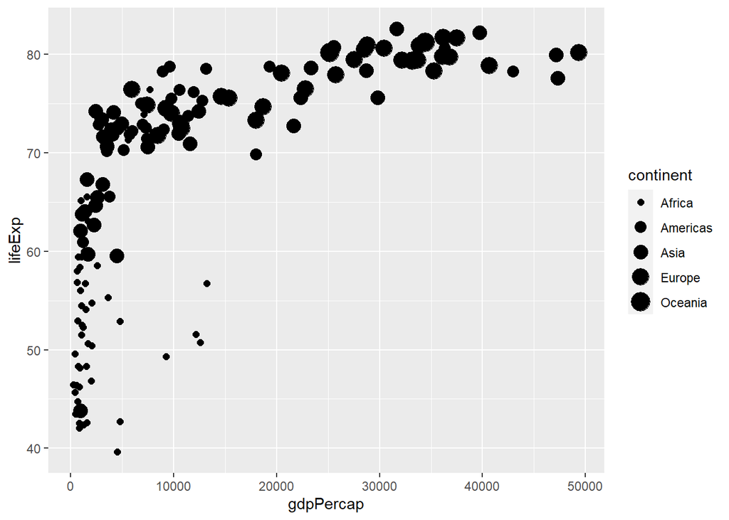

```r
ggplot(data = gapminder07) +
  geom_point(mapping = aes(x = gdpPercap, y = lifeExp, size = continent))
```

Or we could have mapped `continent` to the alpha aesthetic, which controls the transparency of the points, or the shape of the points (also not a good idea in this case).

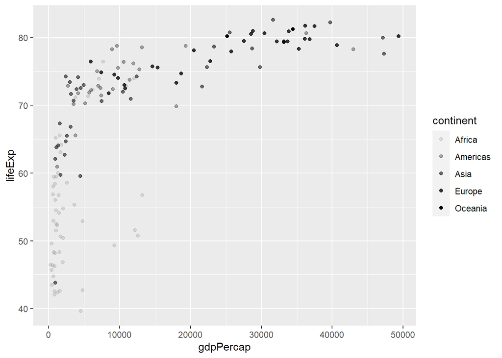

```r
ggplot(data = gapminder07) +
  geom_point(mapping = aes(x = gdpPercap, y = lifeExp, alpha = continent))
```

### Aesthetics outside `aes()`

You can also set the aesthetic properties of your geom manually. For example, we can make all of the points in our plot blue:

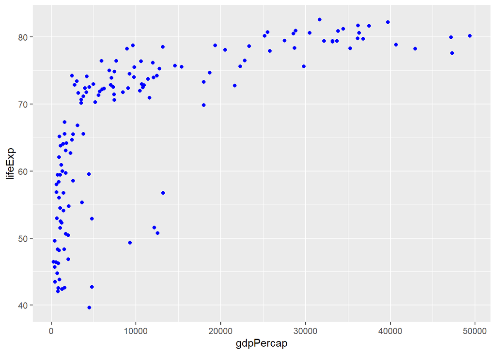

```r
ggplot(data = gapminder07) +
  geom_point(mapping = aes(x = gdpPercap, y = lifeExp), color = "blue")
```

In this graph, the color doesn’t convey information about a variable, but only changes the appearance of the plot. To set an aesthetic manually, set the aesthetic by name as an argument of your geom function; i.e. it goes outside of `aes()`. You’ll need to pick a level that makes sense for that aesthetic:

- The name of a color as a character string.
- The size of a point in mm.
- The shape of a point.

## Facets

One way to add additional variables is with aesthetics. Another way, particularly useful for categorical variables (e.g., continent, poor vs rich, rather than numerical, GDP per capita, life expectancy), is to split your plot into **facets**, subplots that each display one subset of the data.

To facet your plot by a single variable, use `facet_wrap()`. The first argument of `facet_wrap()` should be a formula, which you create with `~` followed by a variable name (e.g. `continent`). The variable that you pass to `facet_wrap()` should be discrete.

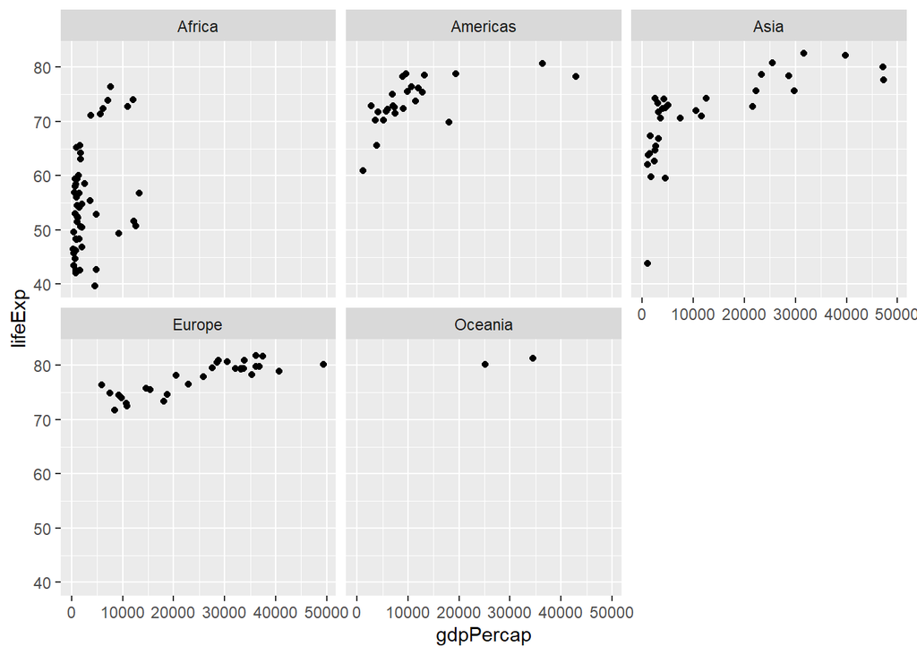

```r
ggplot(data = gapminder07) +
  geom_point(mapping = aes(x = gdpPercap, y = lifeExp))+
  facet_wrap(~continent)
```

To facet your plot on the combination of two variables, add facet_grid() to your plot call. The first argument of facet_grid() is also a formula. This time the formula should contain two variable names separated by a ~. To try this, we can create the Gapminder data with two different years, 1952 and 2007:

```r
gapminder5207 <- filter(gapminder, year==1952 | year==2007)
```

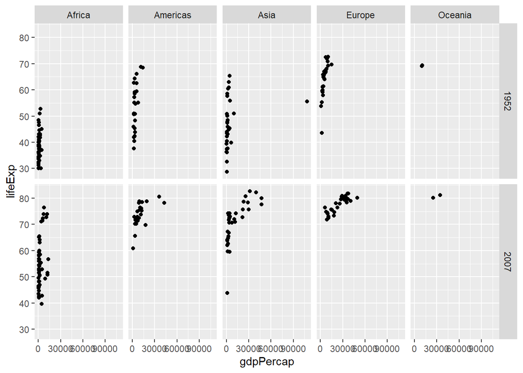

```r
ggplot(data = gapminder5207) +
  geom_point(mapping = aes(x = gdpPercap, y = lifeExp))+
  facet_grid(year ~ continent)
```

## Rescale Axis

In research, it is common for us to re-scale our variables, because their are flaws with the original values or the original values do not match our research purposes.

GDP per capita is often re-scaled by log (aka log transformations). This helps our data points to be more “linear.” To do this in a `ggplot`, write the code:

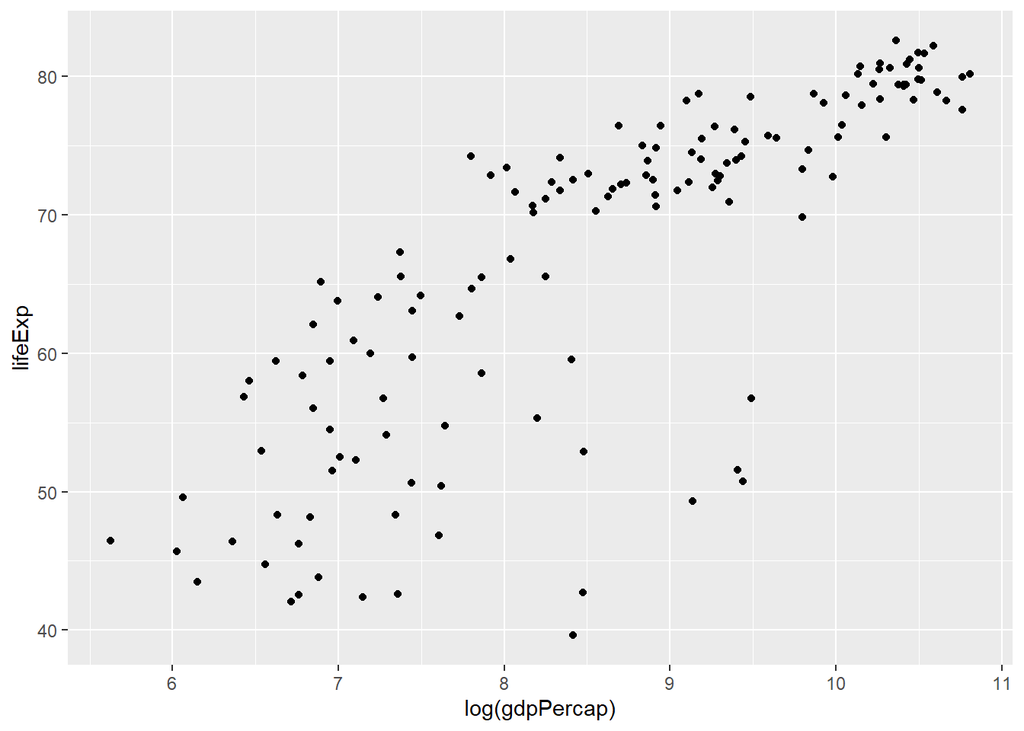

```r
ggplot(data = gapminder07) +
    geom_point(mapping = aes(x = log(gdpPercap), y = lifeExp))
```

You can draw the same graph using different codes:

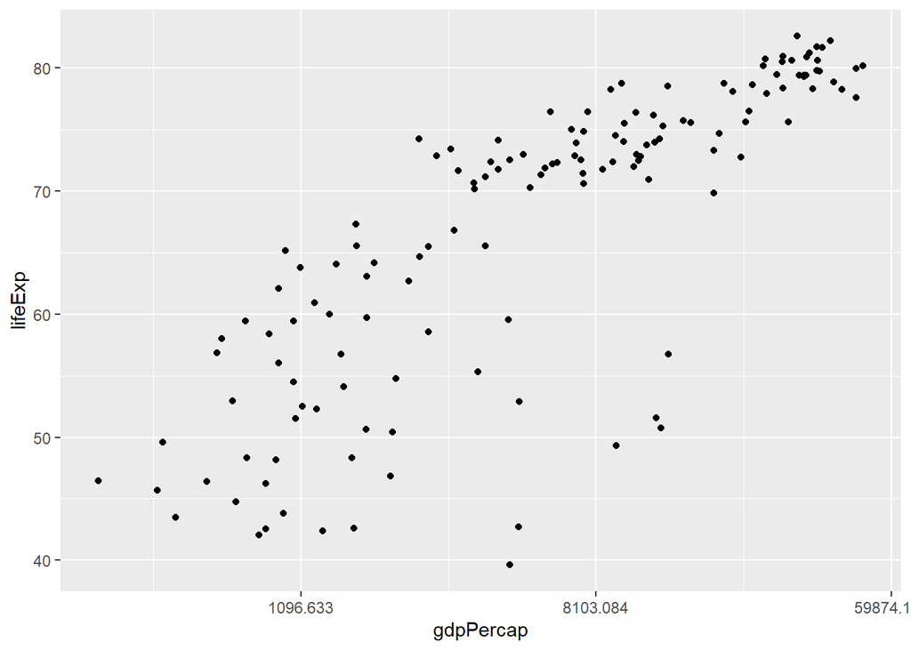

```r
ggplot(data = gapminder07) +
    geom_point(mapping = aes(x = gdpPercap, y = lifeExp))+
  scale_x_continuous(trans = 'log')
```

Similarly, to categorize countries by the `continent` variable and the color aesthetic, write

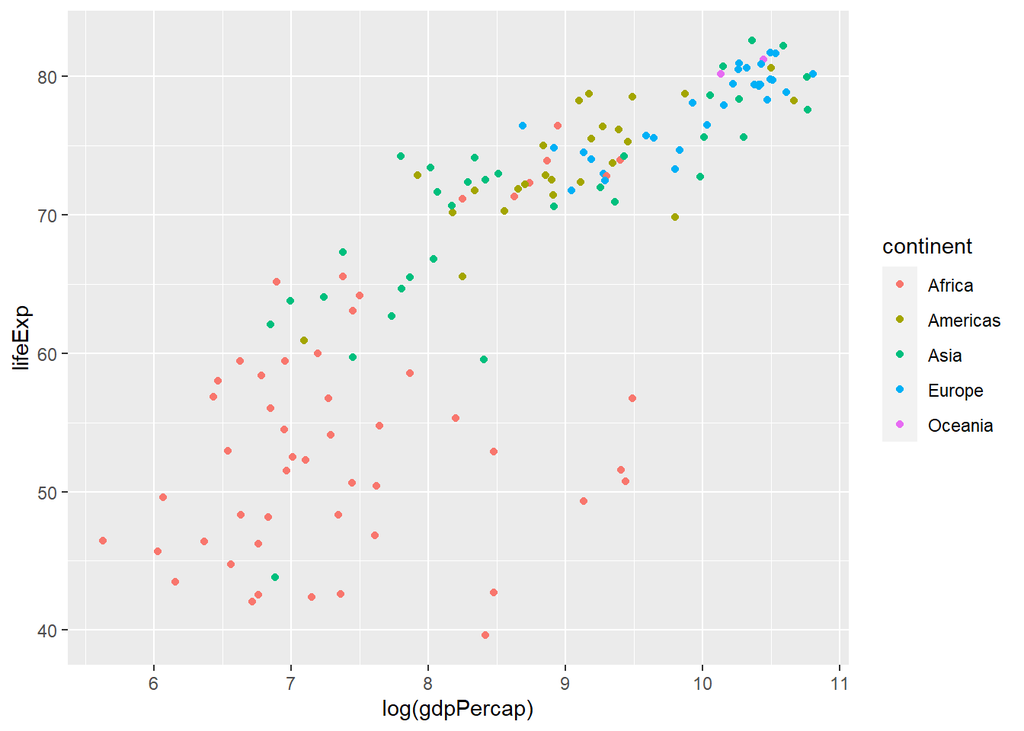

```r
ggplot(data = gapminder07) +
    geom_point(mapping = aes(x = log(gdpPercap), y = lifeExp, color=continent))
```

## Geometric Objects

We have just look at **aesthetics** of `ggplot2`. Now let’s turn to another important component, **geometric objects**.

First, how are these two plots similar?

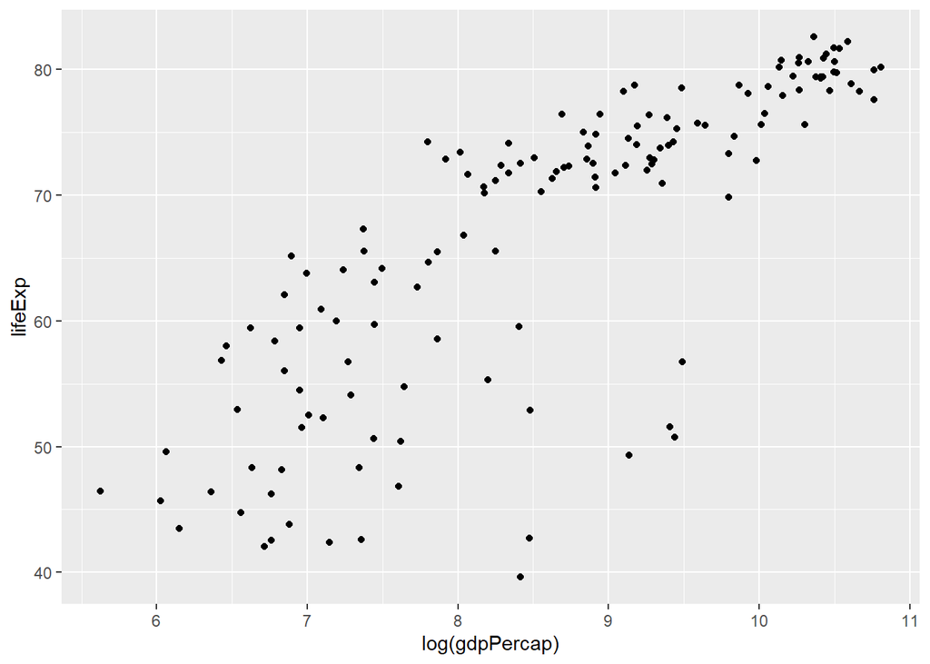

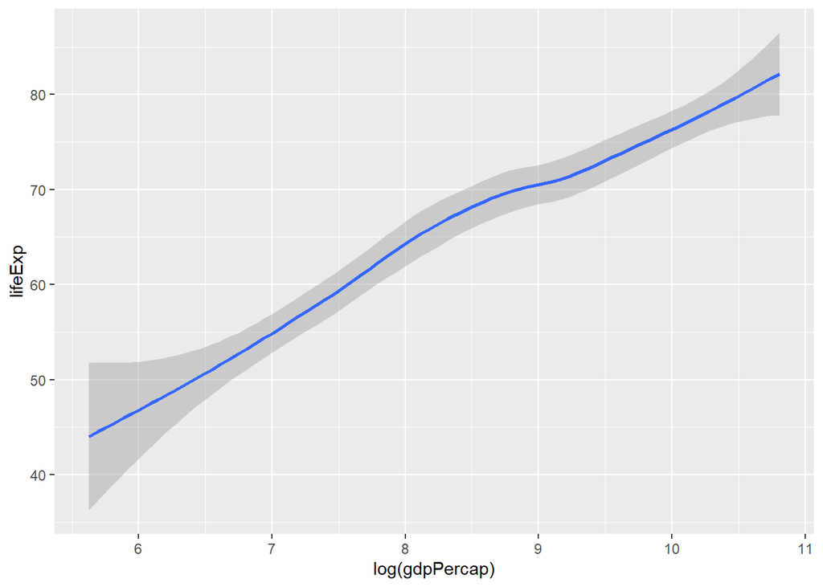

Both plots contain the same x variable, the same y variable, and both describe the same data. But the plots are not identical. Each plot uses a different visual object to represent the data. In `ggplot2` syntax, we say that they use different **geoms**.

A **geom** is the geometrical object that a plot uses to represent data. People often describe plots by the type of **geom** that the plot uses. For example, bar charts use **bar geoms** (`geom_bar`), line charts use line geoms (`geom_line`), box plots use box plot geoms (`geom_box`), and so on. Scatter plots break the trend; they use the point geom (`geom_point`) as we have seen earlier. As we see above, you can use different **geoms** to plot the same data. The plots above use the point geom (`geom_point`) and the smooth geom (`geom_smooth`), a smooth line fitted to the data, respectively.

In other words, you can create graphs in different types, such as scatter plot, line graph, smooth graph, bar plot, and so on. The type of graph to create depends solely on your graphing purposes and research questions.

To change the geom in your plot, change the geom function that added to `ggplot()`. For instance, to make the two plots above, you can use this code:

```r
# Scatter plot
ggplot(data = gapminder07) +
    geom_point(mapping = aes(x = log(gdpPercap), y = lifeExp))

# Smooth curve plot
ggplot(data = gapminder07) +
    geom_smooth(mapping = aes(x = log(gdpPercap), y = lifeExp))
```

`ggplot2` provides over 30 geoms. Every geom function in `ggplot2` takes a `mapping` argument. That means you can assign aesthetics to geoms. However, not every aesthetic works with every geom. You could set the shape of a point, but you couldn’t set the “shape” of a line. On the other hand, you could set the line type of a line. `geom_smooth()` can draw a different line, with a different line type, but it is impossible to achieve with `geom_point`. However, some aesthetics, such as color, can be applied to nearly all geoms.

### Text Plot

Here is another example, text plot, associated with GDP per capita and life expectancy in `gapminder07`. A Text plot requires us to specify the label/text that to be added on the graph.

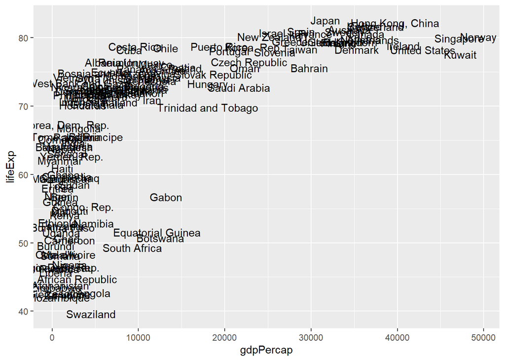

```r
ggplot(data = gapminder07) +
    geom_text(mapping = aes(x = gdpPercap, y = lifeExp, label = country))
```

Similarly, we can re-scale the x-axis.

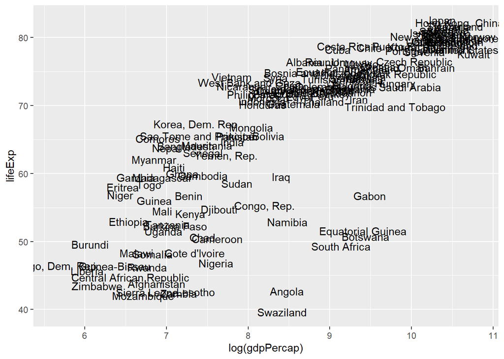

```r
ggplot(data = gapminder07) +
    geom_text(mapping = aes(x = log(gdpPercap), y = lifeExp, label = country))
```

### Bar Plot

Next, let’s take a look at a bar chart. Bar charts seem simple, but they are interesting because they reveal something subtle about plots. Consider a basic bar chart, as drawn with `geom_bar()`. The following chart displays the total number of countries in the `gapminder07` dataset, grouped by `continent`.

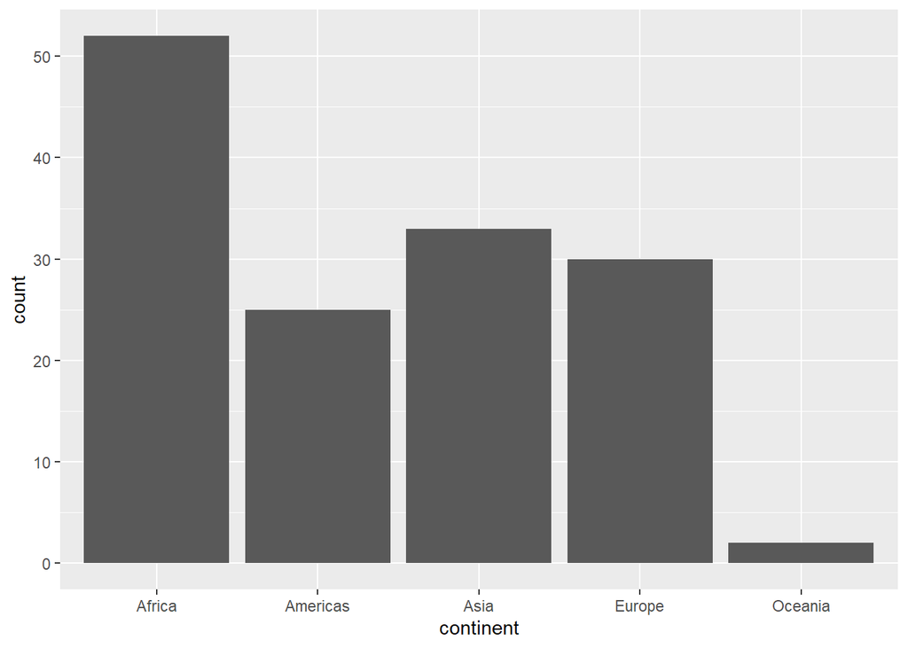

```r
ggplot(data = gapminder07) + geom_bar(mapping = aes(x = continent))
```

Note that the `geom_bar` can always only have one of x or y aesthetic since bar plots, similar to histograms and frequency plots, are designed to show the distributions of variables.

## Combined Graphs

Layering different geoms together, such as `geom_point` and `geom_smooth` allows us to have two different geoms in the same graph! If this makes you excited, buckle up. In this section, we will discuss how to place multiple geoms in the same plot. Combining graphs simply means layering multiple (more than two and usually two) geoms together.

### A Graphing Template

In general, ggplot works by starting from plot and adding more components using the + sign. Thus, you could continue the code using

```r
ggplot(data = <DATA>) +
  <GEOM_FUNCTION1>(mapping = aes(<MAPPINGS>)) +
   <GEOM_FUNCTION2>(mapping = aes(<MAPPINGS>))
```

to add a new function. You will see different functions you can add below.

If the `<GEOM_FUNCTION1>` and `<GEOM_FUNCTION2>` are mapped using the identical mapping methods, i.e. `<MAPPINGS1>` and `<MAPPINGS2>` are identical to each other, there is no difference between the following template and the template above.

```r
ggplot(data = <DATA>, mapping = aes(<MAPPINGS>)) +
  <GEOM_FUNCTION1>() +
   <GEOM_FUNCTION2>()
```

However, any tiny differences need to be specified in the `<GEOM_FUNCTION>` (just consider it as combing multiple layers together).

```r
ggplot(data = <DATA>) +
  <GEOM_FUNCTION1>(mapping = aes(<MAPPINGS1>)) +
   <GEOM_FUNCTION2>(mapping = aes(<MAPPINGS2>))
```

Everything in the graphing template section can be illustrated in the following applications.

### Applications

In this part, test if you can understand the code by yourselves. Once you understand them, you can create similar and even more complex graphs on your own.

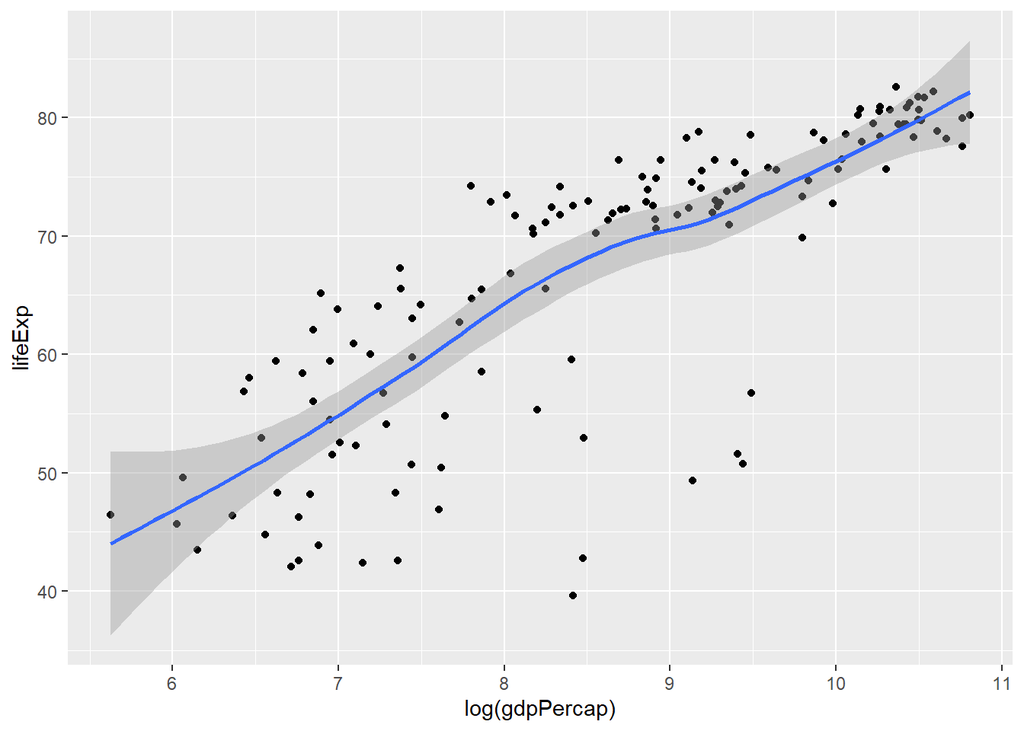

```r
ggplot(data = gapminder07) +
    geom_point(mapping = aes(x = log(gdpPercap), y = lifeExp))+
  geom_smooth(mapping = aes(x = log(gdpPercap), y = lifeExp))
```

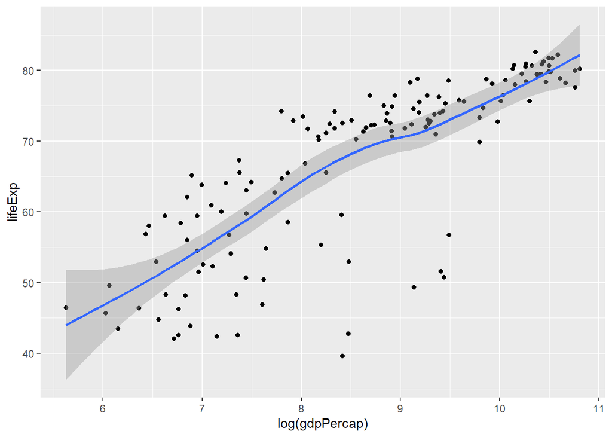

```r
ggplot(data = gapminder07,mapping = aes(x = log(gdpPercap), y = lifeExp))+geom_point()+geom_smooth()
```

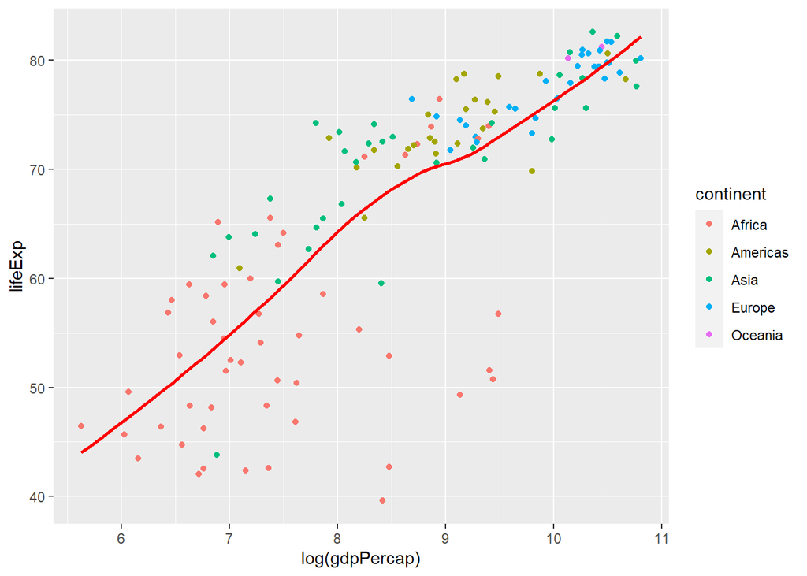

```r
ggplot(data = gapminder07)+geom_point(mapping = aes(x = log(gdpPercap), y = lifeExp,color=continent))+geom_smooth(mapping = aes(x=log(gdpPercap),y=lifeExp),color="red",se=FALSE)
```

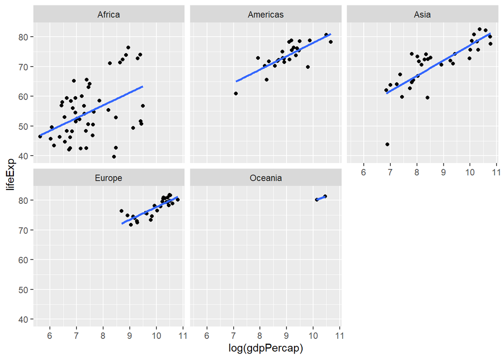

```r
ggplot(data = gapminder07,mapping = aes(x = log(gdpPercap), y = lifeExp))+geom_point()+geom_smooth(method="lm",se=FALSE)+facet_wrap(~continent)
```

### Practice

Recreate the R code necessary to generate the following two graphs.

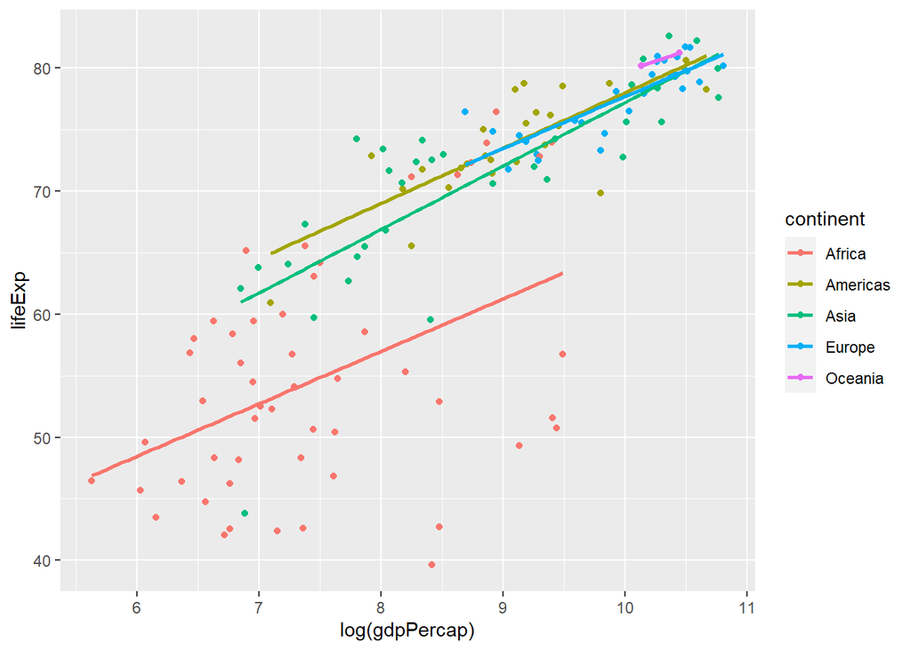

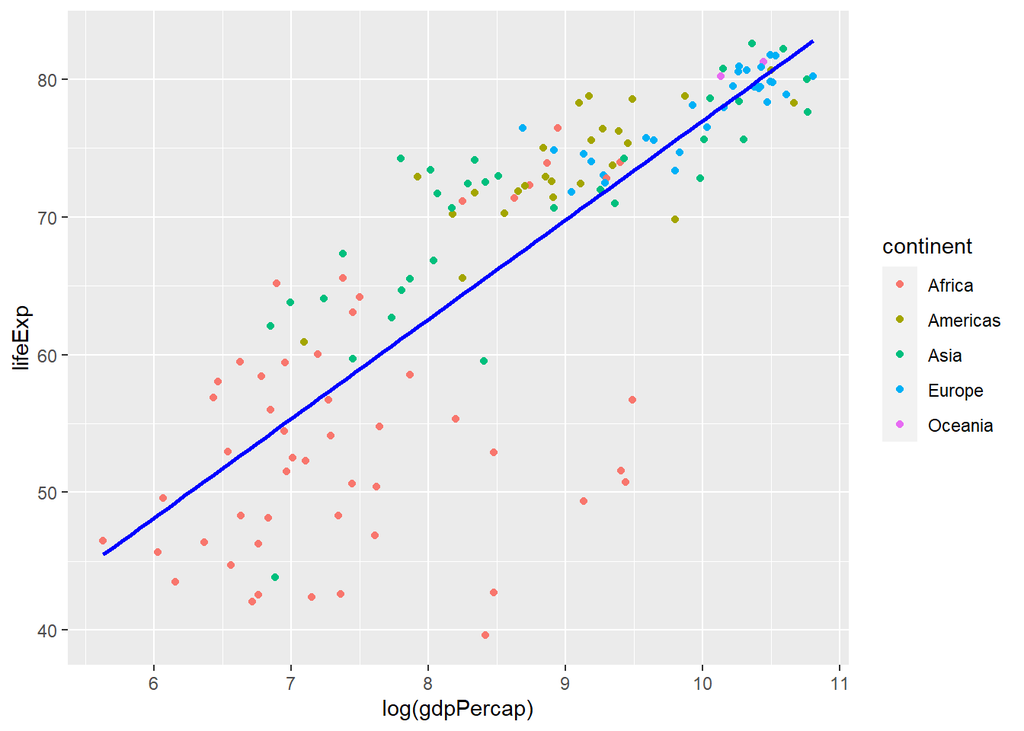

## Common Problems

As you start to run R code, you’re likely to run into problems. Don’t worry — it happens to everyone. I write R code frequently but I still write code that doesn’t work!

Start by carefully comparing the code that you’re running to the code in the handout. Computer languages are extremely picky, and a misplaced character can make all the difference. For example, make sure that every `(` is matched with a `)` and every `"` is paired with another `"`.

One common problem when creating ggplot2 graphics is to put the + in the wrong place: it has to come at the end of the line, not the start. In other words, make sure you haven’t accidentally written code like this:

```r
ggplot(data = gapminder07)
  + geom_point(mapping = aes(x = gdpPercap, y = lifeExp))
```

If you’re still stuck, try the help. You can get help about any R function by running `?function_name` in the console. Don’t worry if the help doesn’t seem that helpful - instead skip down to the examples and look for code that matches what you’re trying to do.

If that doesn’t help, carefully read the error message. Sometimes the answer will be buried there! But when you’re new to R, the answer might be in the error message but you don’t yet know how to understand it. Another great tool is Google: try Googling the error message, as it’s likely someone else has had the same problem, and has gotten help online.